# Telco-Customer-Churn slides

### Telco Customer Churn

The goal is to analyze all relevant customer data and predict behavior to retain customers.

### What is the structure of your dataset?

#### Columns Descriptions:

- **`customerID`**
- **`gender`:** male or female
- **`SeniorCitizen`:** Whether the customer is a senior citizen or not (1, 0) (an elderly person especially : one who has retired)
- **`Partner`:** Whether the customer has a partner or not (Yes, No)
- **`Dependents`:** Whether the customer has dependents or not (Yes, No)
- **`tenure`:** Number of months the customer has stayed with the company
- **`PhoneService`:** Whether the customer has a phone service or not (Yes, No)
- **`MultipleLines`:** Whether the customer has multiple lines or not (Yes, No, No phone service)
- **`InternetService`:** Customer’s internet service provider (DSL, Fiber optic, No)
- **`OnlineSecurity`:** Whether the customer has online security or not (Yes, No, No internet service)
- **`OnlineBackup`:** Whether the customer has online backup or not (Yes, No, No internet service)

#### Columns Descriptions:

- **`DeviceProtection`:** Whether the customer has device protection or not (Yes, No, No internet service)
- **`TechSupport`:** Whether the customer has tech support or not (Yes, No, No internet service)
- **`StreamingTV`:** Whether the customer has streaming TV or not (Yes, No, No internet service)
- **`StreamingMovies`:** Whether the customer has streaming movies or not (Yes, No, No internet service)
- **`Contract`:** The contract term of the customer (Month-to-month, One year, Two year)
- **`PaperlessBilling`:** Whether the customer has paperless billing or not (Yes, No)
- **`PaymentMethod`:** The customer’s payment method (Electronic check, Mailed check, Bank transfer (automatic), Credit card (automatic))
- **`MonthlyCharges`:** The amount charged to the customer monthly
- **`TotalCharges`:** The total amount charged to the customer
- **`Churn`:** Whether the customer churned or not (Yes or No)

### What is/are the main feature(s) of interest in your dataset?

I'm most interested in figuring out what features are best for predicting the customers churn.

#### Distribution of Monthly Charges

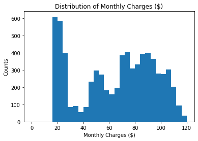

```python
bins = np.arange(0, df.Monthlycharges.max()+4, 4)
plt.hist(df.Monthlycharges, bins=bins);
plt.xlabel('Monthly Charges ($)');
plt.ylabel('Counts');
plt.title('Distribution of Monthly Charges ($)');
```

#### Distribution of Tenures

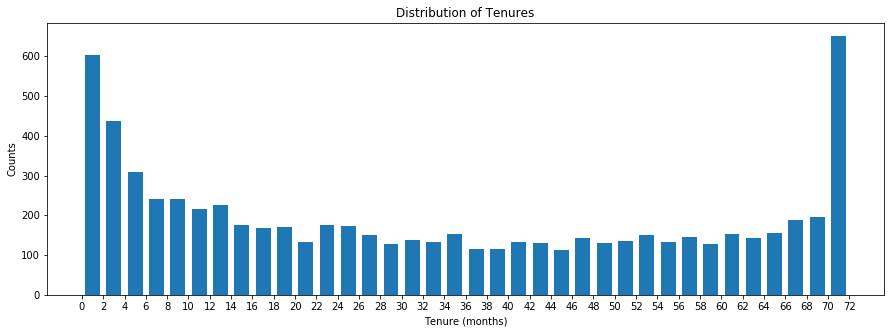

```python
plt.figure(figsize=(15,5))
bins = np.arange(df.Tenure.min(), df.Tenure.max()+2, 2)
plt.hist(df.Tenure, bins=bins, rwidth=0.7);
plt.xticks(np.arange(df.Tenure.min(), df.Tenure.max()+2, 2));
plt.xlabel('Tenure (months)');
plt.ylabel('Counts');
plt.title('Distribution of Tenures');
```

From the distribution it seems we have two peaks that indicates we have loyal customers that have remained with company 6 years and newly joined customers with stay of 0-1 month only.

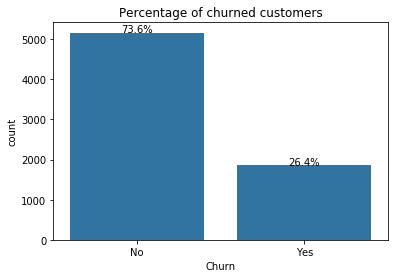

```python
uni_cat_plot(df.Churn)
plt.title('Percentage of churned customers');
```

Most of the dataset have non-churned customers

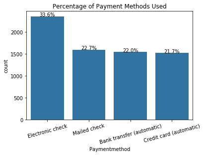

```python
uni_cat_plot(df.Paymentmethod, 15)
plt.title('Percentage of Payment Methods Used');
```

Most of the customers prefer electronic check

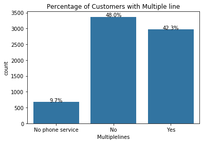

```python
uni_cat_plot(df.Multiplelines)
plt.title('Percentage of Customers with Multiple line');
```

Most of customers have single lines

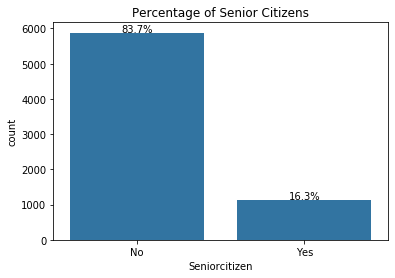

```python
uni_cat_plot(df.Seniorcitizen)
plt.title('Percentage of Senior Citizens');
plt.xticks([0,1], ['No', 'Yes']);
```

Most of the customers are not seniors

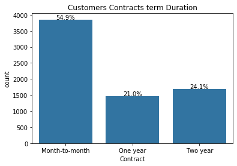

```python
uni_cat_plot(df.Contract)
plt.title('Customers Contracts term Duration');
```

Customers prefer monthly contracts than long term ones

#### Monthly Charges Vs. Tenure

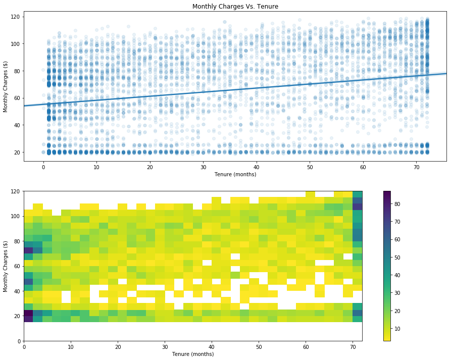

```python
plt.figure(figsize=(15,12))

plt.subplot(2,1,1)
sb.regplot(x=df.Tenure, y=df.Monthlycharges, truncate=False, x_jitter=0.05, scatter_kws={'alpha':0.09})
plt.ylabel('Monthly Charges ($)');
plt.xlabel('Tenure (months)');
plt.title('Monthly Charges Vs. Tenure');


plt.subplot(2,1,2)
bins_x = np.arange(df.Tenure.min(), df.Tenure.max()+2, 2)
bins_y = np.arange(0, df.Monthlycharges.max()+5, 5)
h2d = plt.hist2d(x=df.Tenure, y=df.Monthlycharges, cmap='viridis_r', cmin=3, bins=[bins_x, bins_y]);
plt.colorbar();
plt.ylabel('Monthly Charges ($)');
plt.xlabel('Tenure (months)');
```

As from scatter distribution above and intutively, it appears that loyal customers are with highest monthly charges, and as customer stays for longer period a more trust is bulit therefore higher charges.

Interestingly from the heatmap, it appears that more new customers have higher monthly charges (around 70 dollars) than customers that stayed in company for 2.5-4 years

#### Monthly Charges Vs. Churn

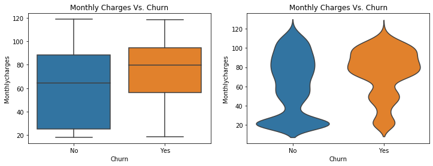

```python
plt.figure(figsize=(12,4))
plt.subplot(1,2,1)
sb.boxplot(x=df.Churn, y=df.Monthlycharges);
plt.title('Monthly Charges Vs. Churn');

plt.subplot(1,2,2)
sb.violinplot(x=df.Churn, y=df.Monthlycharges, inner=None);
plt.title('Monthly Charges Vs. Churn');
```

As we can see customers whose monthly charges are high are more likely to leave the company. We also can see most of churned customers their monthly charges were high in the range of 80-100 dollars. Therefore, we can infer than customers churn due to high monthly charges.

#### Contract Vs. Churn

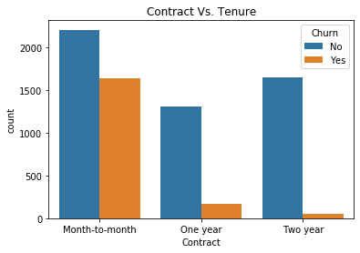

```python
sb.countplot(x=df.Contract, hue=df.Churn);
plt.title('Contract Vs. Tenure');
```

As we can see customers whose contracts are monthly basis are very likely to leave the company, compared to customers with one year contract and very much less likely for two year contract.

#### Churn Vs. Senior Citizens

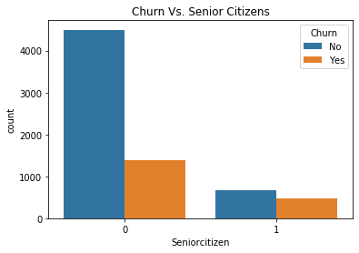

```python
sb.countplot(x=df.Seniorcitizen, hue=df.Churn);
plt.title('Churn Vs. Senior Citizens');
```

It looks like that Senior citizen is much more likely to leave the company than younger citizens

#### Monthly Charges Vs. Churn Vs. Senior Citizens

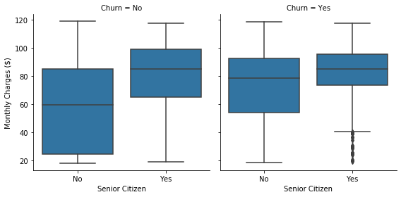

```python
g = sb.FacetGrid(data=df, col='Churn', height = 4);
g.map(sb.boxplot, 'Seniorcitizen', 'Monthlycharges', order=df.Seniorcitizen.value_counts().index);
g.set_ylabels('Monthly Charges ($)');
g.set_xlabels('Senior Citizen');
plt.xticks([0,1],['No', 'Yes']);
```

We can see that Senior Citizens monthly charges are much higher han younger citizens, where median for no churn of senior is equals to 3rd quartile of juniors. We can also see for senior who churned the range of prices were in 80-100 dollars most of the time than those who didn't churn, had more variability in monthly charges

#### Contract Vs. Streaming Movies Vs. Churn

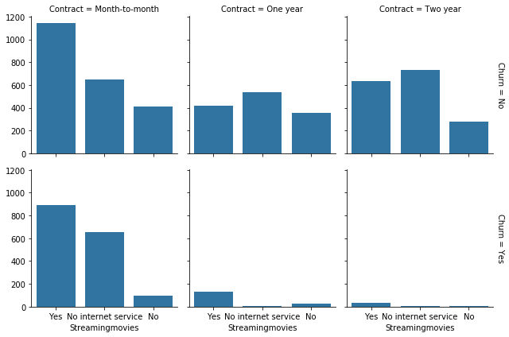

```python
g = sb.FacetGrid(data=df, col='Contract', row='Churn', margin_titles=True);
g.map(sb.countplot, 'Streamingmovies');
```

For no Churn:

- There are more customers using streaming movies services in a month-month contract than one and two years contract due to mostly no internet service

For Churned Customers:

- For monthly contract it most of customers are streaming movies also. But interstingly for longer duration contracts such as one and two years most of them were streaming movies and they churned

So from these two insights we can infer than either streaming movies is expensive for longer contracts which should be unlikely or the streaming service itself is not likeable to the customers and has a factor even if it is small for them to churn